# Risk Factor Analysis

## Outcome Variable

**Outcome Variable:** sstunted

## Predictor Variables

**Intervention Variable:** hhwealth_quart

**Adjustment Set:**

unadjusted

## Stratifying Variables

The analysis was stratified on these variable(s):

- agecat
- studyid
- country

## Data Summary

| agecat | studyid | country | A | n | nA | nAY0 | nAY1 |
| --- | --- | --- | --- | --- | --- | --- | --- |
| Birth | ki0047075b-MAL-ED | BANGLADESH | Wealth Q4 | 82 | 26 | 26 | 0 |
| Birth | ki0047075b-MAL-ED | BANGLADESH | Wealth Q1 | 82 | 4 | 4 | 0 |
| Birth | ki0047075b-MAL-ED | BANGLADESH | Wealth Q2 | 82 | 15 | 13 | 2 |
| Birth | ki0047075b-MAL-ED | BANGLADESH | Wealth Q3 | 82 | 37 | 35 | 2 |
| Birth | ki0047075b-MAL-ED | BRAZIL | Wealth Q4 | 3 | 2 | 2 | 0 |
| Birth | ki0047075b-MAL-ED | BRAZIL | Wealth Q1 | 3 | 0 | 0 | 0 |
| Birth | ki0047075b-MAL-ED | BRAZIL | Wealth Q2 | 3 | 1 | 1 | 0 |
| Birth | ki0047075b-MAL-ED | BRAZIL | Wealth Q3 | 3 | 0 | 0 | 0 |
| Birth | ki0047075b-MAL-ED | INDIA | Wealth Q4 | 55 | 21 | 19 | 2 |
| Birth | ki0047075b-MAL-ED | INDIA | Wealth Q1 | 55 | 1 | 1 | 0 |
| Birth | ki0047075b-MAL-ED | INDIA | Wealth Q2 | 55 | 9 | 9 | 0 |
| Birth | ki0047075b-MAL-ED | INDIA | Wealth Q3 | 55 | 24 | 23 | 1 |
| Birth | ki0047075b-MAL-ED | NEPAL | Wealth Q4 | 31 | 14 | 13 | 1 |
| Birth | ki0047075b-MAL-ED | NEPAL | Wealth Q1 | 31 | 11 | 11 | 0 |
| Birth | ki0047075b-MAL-ED | NEPAL | Wealth Q2 | 31 | 4 | 4 | 0 |
| Birth | ki0047075b-MAL-ED | NEPAL | Wealth Q3 | 31 | 2 | 2 | 0 |
| Birth | ki0047075b-MAL-ED | PERU | Wealth Q4 | 36 | 1 | 1 | 0 |
| Birth | ki0047075b-MAL-ED | PERU | Wealth Q1 | 36 | 23 | 23 | 0 |
| Birth | ki0047075b-MAL-ED | PERU | Wealth Q2 | 36 | 11 | 11 | 0 |
| Birth | ki0047075b-MAL-ED | PERU | Wealth Q3 | 36 | 1 | 1 | 0 |
| Birth | ki0047075b-MAL-ED | SOUTH AFRICA | Wealth Q4 | 61 | 12 | 12 | 0 |
| Birth | ki0047075b-MAL-ED | SOUTH AFRICA | Wealth Q1 | 61 | 10 | 10 | 0 |
| Birth | ki0047075b-MAL-ED | SOUTH AFRICA | Wealth Q2 | 61 | 22 | 22 | 0 |
| Birth | ki0047075b-MAL-ED | SOUTH AFRICA | Wealth Q3 | 61 | 17 | 17 | 0 |
| Birth | ki0047075b-MAL-ED | TANZANIA, UNITED REPUBLIC OF | Wealth Q4 | 23 | 0 | 0 | 0 |
| Birth | ki0047075b-MAL-ED | TANZANIA, UNITED REPUBLIC OF | Wealth Q1 | 23 | 16 | 16 | 0 |
| Birth | ki0047075b-MAL-ED | TANZANIA, UNITED REPUBLIC OF | Wealth Q2 | 23 | 7 | 7 | 0 |
| Birth | ki0047075b-MAL-ED | TANZANIA, UNITED REPUBLIC OF | Wealth Q3 | 23 | 0 | 0 | 0 |
| Birth | ki1000108-CMC-V-BCS-2002 | INDIA | Wealth Q4 | 90 | 31 | 31 | 0 |
| Birth | ki1000108-CMC-V-BCS-2002 | INDIA | Wealth Q1 | 90 | 14 | 14 | 0 |

[output cut: 398 more lines]

The following strata were considered:

- agecat: 12 months, studyid: ki0047075b-MAL-ED, country: BANGLADESH
- agecat: 12 months, studyid: ki0047075b-MAL-ED, country: BRAZIL
- agecat: 12 months, studyid: ki0047075b-MAL-ED, country: INDIA
- agecat: 12 months, studyid: ki0047075b-MAL-ED, country: NEPAL
- agecat: 12 months, studyid: ki0047075b-MAL-ED, country: PERU
- agecat: 12 months, studyid: ki0047075b-MAL-ED, country: SOUTH AFRICA
- agecat: 12 months, studyid: ki0047075b-MAL-ED, country: TANZANIA, UNITED REPUBLIC OF
- agecat: 12 months, studyid: ki1000108-CMC-V-BCS-2002, country: INDIA
- agecat: 12 months, studyid: ki1000108-IRC, country: INDIA
- agecat: 12 months, studyid: ki1017093b-PROVIDE, country: BANGLADESH
- agecat: 12 months, studyid: ki1066203-TanzaniaChild2, country: TANZANIA, UNITED REPUBLIC OF
- agecat: 12 months, studyid: ki1113344-GMS-Nepal, country: NEPAL
- agecat: 12 months, studyid: ki1114097-CONTENT, country: PERU
- agecat: 12 months, studyid: ki1135781-COHORTS, country: GUATEMALA
- agecat: 12 months, studyid: ki1135781-COHORTS, country: PHILIPPINES
- agecat: 12 months, studyid: ki1148112-LCNI-5, country: MALAWI
- agecat: 18 months, studyid: ki0047075b-MAL-ED, country: BANGLADESH
- agecat: 18 months, studyid: ki0047075b-MAL-ED, country: BRAZIL
- agecat: 18 months, studyid: ki0047075b-MAL-ED, country: INDIA
- agecat: 18 months, studyid: ki0047075b-MAL-ED, country: NEPAL
- agecat: 18 months, studyid: ki0047075b-MAL-ED, country: PERU
- agecat: 18 months, studyid: ki0047075b-MAL-ED, country: SOUTH AFRICA
- agecat: 18 months, studyid: ki0047075b-MAL-ED, country: TANZANIA, UNITED REPUBLIC OF
- agecat: 18 months, studyid: ki1000108-CMC-V-BCS-2002, country: INDIA
- agecat: 18 months, studyid: ki1000108-IRC, country: INDIA
- agecat: 18 months, studyid: ki1017093b-PROVIDE, country: BANGLADESH
- agecat: 18 months, studyid: ki1066203-TanzaniaChild2, country: TANZANIA, UNITED REPUBLIC OF
- agecat: 18 months, studyid: ki1113344-GMS-Nepal, country: NEPAL
- agecat: 18 months, studyid: ki1114097-CONTENT, country: PERU
- agecat: 18 months, studyid: ki1135781-COHORTS, country: GUATEMALA
- agecat: 18 months, studyid: ki1135781-COHORTS, country: PHILIPPINES
- agecat: 18 months, studyid: ki1148112-LCNI-5, country: MALAWI
- agecat: 24 months, studyid: ki0047075b-MAL-ED, country: BANGLADESH
- agecat: 24 months, studyid: ki0047075b-MAL-ED, country: BRAZIL
- agecat: 24 months, studyid: ki0047075b-MAL-ED, country: INDIA
- agecat: 24 months, studyid: ki0047075b-MAL-ED, country: NEPAL
- agecat: 24 months, studyid: ki0047075b-MAL-ED, country: PERU
- agecat: 24 months, studyid: ki0047075b-MAL-ED, country: SOUTH AFRICA
- agecat: 24 months, studyid: ki0047075b-MAL-ED, country: TANZANIA, UNITED REPUBLIC OF
- agecat: 24 months, studyid: ki1000108-CMC-V-BCS-2002, country: INDIA
- agecat: 24 months, studyid: ki1000108-IRC, country: INDIA
- agecat: 24 months, studyid: ki1017093b-PROVIDE, country: BANGLADESH
- agecat: 24 months, studyid: ki1066203-TanzaniaChild2, country: TANZANIA, UNITED REPUBLIC OF
- agecat: 24 months, studyid: ki1113344-GMS-Nepal, country: NEPAL
- agecat: 24 months, studyid: ki1114097-CONTENT, country: PERU
- agecat: 24 months, studyid: ki1135781-COHORTS, country: GUATEMALA
- agecat: 24 months, studyid: ki1135781-COHORTS, country: PHILIPPINES
- agecat: 24 months, studyid: ki1148112-LCNI-5, country: MALAWI
- agecat: 3 months, studyid: ki0047075b-MAL-ED, country: BANGLADESH
- agecat: 3 months, studyid: ki0047075b-MAL-ED, country: BRAZIL
- agecat: 3 months, studyid: ki0047075b-MAL-ED, country: INDIA
- agecat: 3 months, studyid: ki0047075b-MAL-ED, country: NEPAL
- agecat: 3 months, studyid: ki0047075b-MAL-ED, country: PERU
- agecat: 3 months, studyid: ki0047075b-MAL-ED, country: SOUTH AFRICA
- agecat: 3 months, studyid: ki0047075b-MAL-ED, country: TANZANIA, UNITED REPUBLIC OF
- agecat: 3 months, studyid: ki1000108-CMC-V-BCS-2002, country: INDIA
- agecat: 3 months, studyid: ki1000108-IRC, country: INDIA
- agecat: 3 months, studyid: ki1017093b-PROVIDE, country: BANGLADESH
- agecat: 3 months, studyid: ki1066203-TanzaniaChild2, country: TANZANIA, UNITED REPUBLIC OF
- agecat: 3 months, studyid: ki1113344-GMS-Nepal, country: NEPAL
- agecat: 3 months, studyid: ki1114097-CONTENT, country: PERU
- agecat: 3 months, studyid: ki1135781-COHORTS, country: GUATEMALA
- agecat: 3 months, studyid: ki1135781-COHORTS, country: PHILIPPINES
- agecat: 6 months, studyid: ki0047075b-MAL-ED, country: BANGLADESH
- agecat: 6 months, studyid: ki0047075b-MAL-ED, country: BRAZIL
- agecat: 6 months, studyid: ki0047075b-MAL-ED, country: INDIA
- agecat: 6 months, studyid: ki0047075b-MAL-ED, country: NEPAL
- agecat: 6 months, studyid: ki0047075b-MAL-ED, country: PERU
- agecat: 6 months, studyid: ki0047075b-MAL-ED, country: SOUTH AFRICA
- agecat: 6 months, studyid: ki0047075b-MAL-ED, country: TANZANIA, UNITED REPUBLIC OF
- agecat: 6 months, studyid: ki1000108-CMC-V-BCS-2002, country: INDIA
- agecat: 6 months, studyid: ki1000108-IRC, country: INDIA
- agecat: 6 months, studyid: ki1017093b-PROVIDE, country: BANGLADESH
- agecat: 6 months, studyid: ki1066203-TanzaniaChild2, country: TANZANIA, UNITED REPUBLIC OF
- agecat: 6 months, studyid: ki1113344-GMS-Nepal, country: NEPAL
- agecat: 6 months, studyid: ki1114097-CONTENT, country: PERU
- agecat: 6 months, studyid: ki1135781-COHORTS, country: GUATEMALA
- agecat: 6 months, studyid: ki1135781-COHORTS, country: PHILIPPINES
- agecat: 6 months, studyid: ki1148112-LCNI-5, country: MALAWI
- agecat: 9 months, studyid: ki0047075b-MAL-ED, country: BANGLADESH
- agecat: 9 months, studyid: ki0047075b-MAL-ED, country: BRAZIL
- agecat: 9 months, studyid: ki0047075b-MAL-ED, country: INDIA
- agecat: 9 months, studyid: ki0047075b-MAL-ED, country: NEPAL
- agecat: 9 months, studyid: ki0047075b-MAL-ED, country: PERU
- agecat: 9 months, studyid: ki0047075b-MAL-ED, country: SOUTH AFRICA
- agecat: 9 months, studyid: ki0047075b-MAL-ED, country: TANZANIA, UNITED REPUBLIC OF
- agecat: 9 months, studyid: ki1000108-CMC-V-BCS-2002, country: INDIA
- agecat: 9 months, studyid: ki1000108-IRC, country: INDIA
- agecat: 9 months, studyid: ki1017093b-PROVIDE, country: BANGLADESH
- agecat: 9 months, studyid: ki1066203-TanzaniaChild2, country: TANZANIA, UNITED REPUBLIC OF
- agecat: 9 months, studyid: ki1113344-GMS-Nepal, country: NEPAL
- agecat: 9 months, studyid: ki1114097-CONTENT, country: PERU
- agecat: 9 months, studyid: ki1135781-COHORTS, country: GUATEMALA
- agecat: 9 months, studyid: ki1135781-COHORTS, country: PHILIPPINES
- agecat: 9 months, studyid: ki1148112-LCNI-5, country: MALAWI
- agecat: Birth, studyid: ki0047075b-MAL-ED, country: BANGLADESH
- agecat: Birth, studyid: ki0047075b-MAL-ED, country: BRAZIL
- agecat: Birth, studyid: ki0047075b-MAL-ED, country: INDIA
- agecat: Birth, studyid: ki0047075b-MAL-ED, country: NEPAL
- agecat: Birth, studyid: ki0047075b-MAL-ED, country: PERU
- agecat: Birth, studyid: ki0047075b-MAL-ED, country: SOUTH AFRICA
- agecat: Birth, studyid: ki0047075b-MAL-ED, country: TANZANIA, UNITED REPUBLIC OF
- agecat: Birth, studyid: ki1000108-CMC-V-BCS-2002, country: INDIA
- agecat: Birth, studyid: ki1000108-IRC, country: INDIA
- agecat: Birth, studyid: ki1114097-CONTENT, country: PERU
- agecat: Birth, studyid: ki1135781-COHORTS, country: GUATEMALA
- agecat: Birth, studyid: ki1135781-COHORTS, country: PHILIPPINES

### Dropped Strata

Some strata were dropped due to rare outcomes:

- agecat: Birth, studyid: ki0047075b-MAL-ED, country: BANGLADESH
- agecat: Birth, studyid: ki0047075b-MAL-ED, country: BRAZIL
- agecat: Birth, studyid: ki0047075b-MAL-ED, country: INDIA
- agecat: Birth, studyid: ki0047075b-MAL-ED, country: NEPAL
- agecat: Birth, studyid: ki0047075b-MAL-ED, country: PERU
- agecat: Birth, studyid: ki0047075b-MAL-ED, country: SOUTH AFRICA
- agecat: Birth, studyid: ki0047075b-MAL-ED, country: TANZANIA, UNITED REPUBLIC OF
- agecat: Birth, studyid: ki1000108-CMC-V-BCS-2002, country: INDIA
- agecat: Birth, studyid: ki1000108-IRC, country: INDIA
- agecat: Birth, studyid: ki1114097-CONTENT, country: PERU
- agecat: Birth, studyid: ki1135781-COHORTS, country: GUATEMALA
- agecat: 3 months, studyid: ki0047075b-MAL-ED, country: BANGLADESH
- agecat: 3 months, studyid: ki0047075b-MAL-ED, country: BRAZIL
- agecat: 3 months, studyid: ki0047075b-MAL-ED, country: INDIA
- agecat: 3 months, studyid: ki0047075b-MAL-ED, country: NEPAL
- agecat: 3 months, studyid: ki0047075b-MAL-ED, country: PERU
- agecat: 3 months, studyid: ki0047075b-MAL-ED, country: SOUTH AFRICA
- agecat: 3 months, studyid: ki0047075b-MAL-ED, country: TANZANIA, UNITED REPUBLIC OF
- agecat: 3 months, studyid: ki1017093b-PROVIDE, country: BANGLADESH
- agecat: 3 months, studyid: ki1066203-TanzaniaChild2, country: TANZANIA, UNITED REPUBLIC OF
- agecat: 3 months, studyid: ki1113344-GMS-Nepal, country: NEPAL
- agecat: 3 months, studyid: ki1114097-CONTENT, country: PERU
- agecat: 6 months, studyid: ki0047075b-MAL-ED, country: BANGLADESH
- agecat: 6 months, studyid: ki0047075b-MAL-ED, country: BRAZIL
- agecat: 6 months, studyid: ki0047075b-MAL-ED, country: INDIA
- agecat: 6 months, studyid: ki0047075b-MAL-ED, country: NEPAL
- agecat: 6 months, studyid: ki0047075b-MAL-ED, country: PERU
- agecat: 6 months, studyid: ki0047075b-MAL-ED, country: SOUTH AFRICA
- agecat: 6 months, studyid: ki0047075b-MAL-ED, country: TANZANIA, UNITED REPUBLIC OF
- agecat: 6 months, studyid: ki1000108-CMC-V-BCS-2002, country: INDIA
- agecat: 6 months, studyid: ki1000108-IRC, country: INDIA
- agecat: 6 months, studyid: ki1017093b-PROVIDE, country: BANGLADESH
- agecat: 6 months, studyid: ki1066203-TanzaniaChild2, country: TANZANIA, UNITED REPUBLIC OF
- agecat: 6 months, studyid: ki1113344-GMS-Nepal, country: NEPAL
- agecat: 6 months, studyid: ki1114097-CONTENT, country: PERU
- agecat: 9 months, studyid: ki0047075b-MAL-ED, country: BANGLADESH
- agecat: 9 months, studyid: ki0047075b-MAL-ED, country: BRAZIL
- agecat: 9 months, studyid: ki0047075b-MAL-ED, country: INDIA
- agecat: 9 months, studyid: ki0047075b-MAL-ED, country: NEPAL
- agecat: 9 months, studyid: ki0047075b-MAL-ED, country: PERU
- agecat: 9 months, studyid: ki0047075b-MAL-ED, country: SOUTH AFRICA
- agecat: 9 months, studyid: ki0047075b-MAL-ED, country: TANZANIA, UNITED REPUBLIC OF
- agecat: 9 months, studyid: ki1000108-CMC-V-BCS-2002, country: INDIA
- agecat: 9 months, studyid: ki1017093b-PROVIDE, country: BANGLADESH
- agecat: 9 months, studyid: ki1066203-TanzaniaChild2, country: TANZANIA, UNITED REPUBLIC OF
- agecat: 9 months, studyid: ki1114097-CONTENT, country: PERU
- agecat: 12 months, studyid: ki0047075b-MAL-ED, country: BANGLADESH
- agecat: 12 months, studyid: ki0047075b-MAL-ED, country: BRAZIL
- agecat: 12 months, studyid: ki0047075b-MAL-ED, country: INDIA
- agecat: 12 months, studyid: ki0047075b-MAL-ED, country: NEPAL
- agecat: 12 months, studyid: ki0047075b-MAL-ED, country: PERU
- agecat: 12 months, studyid: ki0047075b-MAL-ED, country: SOUTH AFRICA
- agecat: 12 months, studyid: ki0047075b-MAL-ED, country: TANZANIA, UNITED REPUBLIC OF
- agecat: 12 months, studyid: ki1017093b-PROVIDE, country: BANGLADESH
- agecat: 12 months, studyid: ki1066203-TanzaniaChild2, country: TANZANIA, UNITED REPUBLIC OF
- agecat: 12 months, studyid: ki1114097-CONTENT, country: PERU
- agecat: 18 months, studyid: ki0047075b-MAL-ED, country: BANGLADESH
- agecat: 18 months, studyid: ki0047075b-MAL-ED, country: BRAZIL
- agecat: 18 months, studyid: ki0047075b-MAL-ED, country: INDIA
- agecat: 18 months, studyid: ki0047075b-MAL-ED, country: NEPAL
- agecat: 18 months, studyid: ki0047075b-MAL-ED, country: PERU
- agecat: 18 months, studyid: ki0047075b-MAL-ED, country: SOUTH AFRICA
- agecat: 18 months, studyid: ki0047075b-MAL-ED, country: TANZANIA, UNITED REPUBLIC OF
- agecat: 18 months, studyid: ki1114097-CONTENT, country: PERU
- agecat: 24 months, studyid: ki0047075b-MAL-ED, country: BANGLADESH
- agecat: 24 months, studyid: ki0047075b-MAL-ED, country: BRAZIL
- agecat: 24 months, studyid: ki0047075b-MAL-ED, country: INDIA
- agecat: 24 months, studyid: ki0047075b-MAL-ED, country: NEPAL
- agecat: 24 months, studyid: ki0047075b-MAL-ED, country: PERU
- agecat: 24 months, studyid: ki0047075b-MAL-ED, country: SOUTH AFRICA
- agecat: 24 months, studyid: ki0047075b-MAL-ED, country: TANZANIA, UNITED REPUBLIC OF
- agecat: 24 months, studyid: ki1066203-TanzaniaChild2, country: TANZANIA, UNITED REPUBLIC OF
- agecat: 24 months, studyid: ki1114097-CONTENT, country: PERU

## Methods Detail

We’re interested in the causal parameters $E[Y_a]$ for all values of $a \in \mathcal{A}$. These parameters represent the mean outcome if, possibly contrary to fact, we intervened to set all units to have $A=a$. Under the randomization and positivity assumptions, these are identified by the statistical parameters $\psi_a=E_W[E_{Y|A,W}(Y|A=a,W)]$. In addition, we’re interested in the mean of $Y$, $E[Y]$ under no intervention (the observed mean). We will estimate these parameters by using SuperLearner to fit the relevant likelihood factors – $E_{Y|A,W}(Y|A=a,W)$ and $p(A=a|W)$, and then updating our likelihood fit using a joint TMLE.

For unadjusted analyses ($W=\{\}$), initial likelihoods were estimated using Lrnr_glm to estimate the simple $E(Y|A)$ and Lrnr_mean to estimate $p(A)$. For adjusted analyses, a small library containing Lrnr_glmnet, Lrnr_xgboost, and Lrnr_mean was used.

Having estimated these parameters, we will then use the delta method to estimate relative risks and attributable risks relative to a prespecified baseline level of $A$.

# Results Detail

## Results Plots

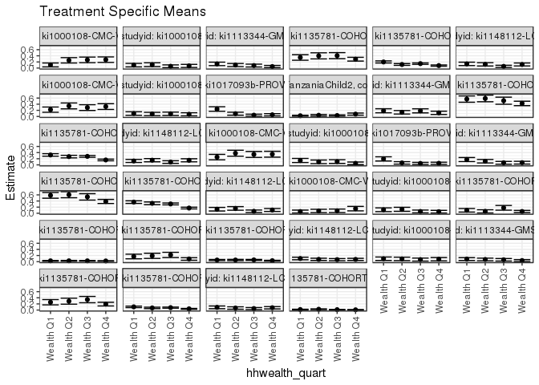

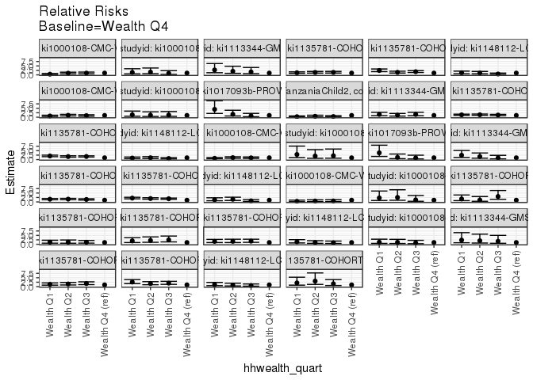

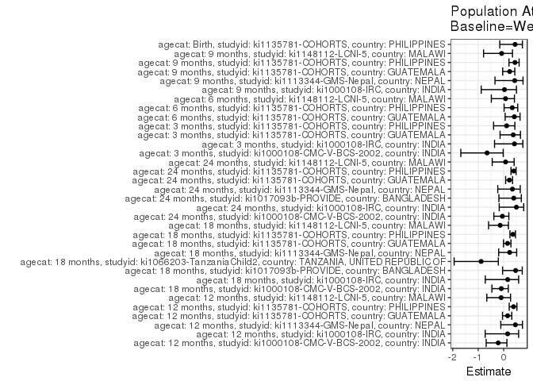

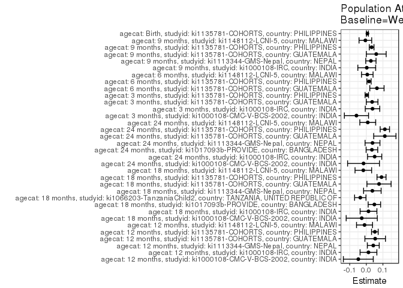

## Results Table

### Parameter: TSM

| agecat | studyid | country | intervention_level | baseline_level | estimate | ci_lower | ci_upper |
| --- | --- | --- | --- | --- | --- | --- | --- |
| Birth | ki1135781-COHORTS | PHILIPPINES | Wealth Q4 | NA | 0.0083135 | 0.0021795 | 0.0144475 |
| Birth | ki1135781-COHORTS | PHILIPPINES | Wealth Q1 | NA | 0.0174672 | 0.0076695 | 0.0272650 |
| Birth | ki1135781-COHORTS | PHILIPPINES | Wealth Q2 | NA | 0.0260223 | 0.0125676 | 0.0394771 |
| Birth | ki1135781-COHORTS | PHILIPPINES | Wealth Q3 | NA | 0.0132383 | 0.0060886 | 0.0203880 |
| 3 months | ki1000108-CMC-V-BCS-2002 | INDIA | Wealth Q4 | NA | 0.1505376 | 0.0777593 | 0.2233159 |
| 3 months | ki1000108-CMC-V-BCS-2002 | INDIA | Wealth Q1 | NA | 0.0555556 | 0.0081663 | 0.1029448 |
| 3 months | ki1000108-CMC-V-BCS-2002 | INDIA | Wealth Q2 | NA | 0.0760870 | 0.0218337 | 0.1303402 |
| 3 months | ki1000108-CMC-V-BCS-2002 | INDIA | Wealth Q3 | NA | 0.0804598 | 0.0232245 | 0.1376951 |
| 3 months | ki1000108-IRC | INDIA | Wealth Q4 | NA | 0.0510204 | 0.0074020 | 0.0946388 |
| 3 months | ki1000108-IRC | INDIA | Wealth Q1 | NA | 0.1142857 | 0.0533558 | 0.1752156 |
| 3 months | ki1000108-IRC | INDIA | Wealth Q2 | NA | 0.1287129 | 0.0633226 | 0.1941032 |
| 3 months | ki1000108-IRC | INDIA | Wealth Q3 | NA | 0.0582524 | 0.0129639 | 0.1035409 |
| 3 months | ki1135781-COHORTS | GUATEMALA | Wealth Q4 | NA | 0.0578035 | 0.0229896 | 0.0926174 |
| 3 months | ki1135781-COHORTS | GUATEMALA | Wealth Q1 | NA | 0.0970874 | 0.0398455 | 0.1543292 |
| 3 months | ki1135781-COHORTS | GUATEMALA | Wealth Q2 | NA | 0.0617284 | 0.0092607 | 0.1141961 |
| 3 months | ki1135781-COHORTS | GUATEMALA | Wealth Q3 | NA | 0.1770833 | 0.1006366 | 0.2535301 |
| 3 months | ki1135781-COHORTS | PHILIPPINES | Wealth Q4 | NA | 0.0227560 | 0.0123620 | 0.0331501 |
| 3 months | ki1135781-COHORTS | PHILIPPINES | Wealth Q1 | NA | 0.0268987 | 0.0142831 | 0.0395144 |
| 3 months | ki1135781-COHORTS | PHILIPPINES | Wealth Q2 | NA | 0.0273438 | 0.0132152 | 0.0414723 |
| 3 months | ki1135781-COHORTS | PHILIPPINES | Wealth Q3 | NA | 0.0266241 | 0.0163257 | 0.0369224 |
| 6 months | ki1135781-COHORTS | GUATEMALA | Wealth Q4 | NA | 0.0882353 | 0.0455498 | 0.1309208 |
| 6 months | ki1135781-COHORTS | GUATEMALA | Wealth Q1 | NA | 0.1684211 | 0.0930802 | 0.2437619 |
| 6 months | ki1135781-COHORTS | GUATEMALA | Wealth Q2 | NA | 0.1904762 | 0.1064068 | 0.2745455 |
| 6 months | ki1135781-COHORTS | GUATEMALA | Wealth Q3 | NA | 0.2197802 | 0.1346028 | 0.3049576 |
| 6 months | ki1135781-COHORTS | PHILIPPINES | Wealth Q4 | NA | 0.0323015 | 0.0195865 | 0.0450164 |
| 6 months | ki1135781-COHORTS | PHILIPPINES | Wealth Q1 | NA | 0.0526316 | 0.0342969 | 0.0709663 |
| 6 months | ki1135781-COHORTS | PHILIPPINES | Wealth Q2 | NA | 0.0536082 | 0.0335585 | 0.0736580 |
| 6 months | ki1135781-COHORTS | PHILIPPINES | Wealth Q3 | NA | 0.0571429 | 0.0420590 | 0.0722267 |
| 6 months | ki1148112-LCNI-5 | MALAWI | Wealth Q4 | NA | 0.0737327 | 0.0389404 | 0.1085250 |
| 6 months | ki1148112-LCNI-5 | MALAWI | Wealth Q1 | NA | 0.1034483 | 0.0615288 | 0.1453677 |

[output cut: 106 more lines]

### Parameter: E(Y)

| agecat | studyid | country | intervention_level | baseline_level | estimate | ci_lower | ci_upper |
| --- | --- | --- | --- | --- | --- | --- | --- |
| Birth | ki1135781-COHORTS | PHILIPPINES | NA | NA | 0.0150869 | 0.0148735 | 0.0153004 |
| 3 months | ki1000108-CMC-V-BCS-2002 | INDIA | NA | NA | 0.0911602 | 0.0874320 | 0.0948884 |
| 3 months | ki1000108-IRC | INDIA | NA | NA | 0.0884521 | 0.0851641 | 0.0917401 |
| 3 months | ki1135781-COHORTS | GUATEMALA | NA | NA | 0.0927152 | 0.0884407 | 0.0969898 |
| 3 months | ki1135781-COHORTS | PHILIPPINES | NA | NA | 0.0257481 | 0.0256801 | 0.0258161 |
| 6 months | ki1135781-COHORTS | GUATEMALA | NA | NA | 0.1522727 | 0.1472685 | 0.1572770 |
| 6 months | ki1135781-COHORTS | PHILIPPINES | NA | NA | 0.0487445 | 0.0483579 | 0.0491310 |
| 6 months | ki1148112-LCNI-5 | MALAWI | NA | NA | 0.0796569 | 0.0786866 | 0.0806271 |
| 9 months | ki1000108-IRC | INDIA | NA | NA | 0.0835381 | 0.0825235 | 0.0845527 |
| 9 months | ki1113344-GMS-Nepal | NEPAL | NA | NA | 0.0635209 | 0.0620012 | 0.0650405 |
| 9 months | ki1135781-COHORTS | GUATEMALA | NA | NA | 0.2540416 | 0.2487965 | 0.2592866 |
| 9 months | ki1135781-COHORTS | PHILIPPINES | NA | NA | 0.0722714 | 0.0714157 | 0.0731271 |
| 9 months | ki1148112-LCNI-5 | MALAWI | NA | NA | 0.0700152 | 0.0689217 | 0.0711087 |
| 12 months | ki1000108-CMC-V-BCS-2002 | INDIA | NA | NA | 0.2255435 | 0.2184295 | 0.2326575 |
| 12 months | ki1000108-IRC | INDIA | NA | NA | 0.0837438 | 0.0817585 | 0.0857292 |
| 12 months | ki1113344-GMS-Nepal | NEPAL | NA | NA | 0.0913978 | 0.0887936 | 0.0940021 |
| 12 months | ki1135781-COHORTS | GUATEMALA | NA | NA | 0.3433134 | 0.3389917 | 0.3476351 |
| 12 months | ki1135781-COHORTS | PHILIPPINES | NA | NA | 0.1330754 | 0.1314711 | 0.1346798 |
| 12 months | ki1148112-LCNI-5 | MALAWI | NA | NA | 0.1062802 | 0.1038193 | 0.1087411 |
| 18 months | ki1000108-CMC-V-BCS-2002 | INDIA | NA | NA | 0.2953930 | 0.2906989 | 0.3000870 |
| 18 months | ki1000108-IRC | INDIA | NA | NA | 0.0839506 | 0.0830436 | 0.0848576 |
| 18 months | ki1017093b-PROVIDE | BANGLADESH | NA | NA | 0.1034483 | 0.0969004 | 0.1099961 |
| 18 months | ki1066203-TanzaniaChild2 | TANZANIA, UNITED REPUBLIC OF | NA | NA | 0.0409417 | 0.0396212 | 0.0422622 |
| 18 months | ki1113344-GMS-Nepal | NEPAL | NA | NA | 0.1545455 | 0.1520853 | 0.1570056 |
| 18 months | ki1135781-COHORTS | GUATEMALA | NA | NA | 0.5011876 | 0.4945239 | 0.5078514 |
| 18 months | ki1135781-COHORTS | PHILIPPINES | NA | NA | 0.2516051 | 0.2492294 | 0.2539809 |
| 18 months | ki1148112-LCNI-5 | MALAWI | NA | NA | 0.1307371 | 0.1289881 | 0.1324862 |
| 24 months | ki1000108-CMC-V-BCS-2002 | INDIA | NA | NA | 0.3306452 | 0.3258983 | 0.3353920 |
| 24 months | ki1000108-IRC | INDIA | NA | NA | 0.1002445 | 0.0970342 | 0.1034548 |
| 24 months | ki1017093b-PROVIDE | BANGLADESH | NA | NA | 0.0850694 | 0.0802699 | 0.0898690 |
| 24 months | ki1113344-GMS-Nepal | NEPAL | NA | NA | 0.1082164 | 0.1044275 | 0.1120053 |
| 24 months | ki1135781-COHORTS | GUATEMALA | NA | NA | 0.4969819 | 0.4885307 | 0.5054331 |
| 24 months | ki1135781-COHORTS | PHILIPPINES | NA | NA | 0.2817996 | 0.2789014 | 0.2846978 |
| 24 months | ki1148112-LCNI-5 | MALAWI | NA | NA | 0.1149826 | 0.1121983 | 0.1177668 |

### Parameter: RR

| agecat | studyid | country | intervention_level | baseline_level | estimate | ci_lower | ci_upper |
| --- | --- | --- | --- | --- | --- | --- | --- |
| Birth | ki1135781-COHORTS | PHILIPPINES | Wealth Q4 | Wealth Q4 | 1.0000000 | 1.0000000 | 1.0000000 |
| Birth | ki1135781-COHORTS | PHILIPPINES | Wealth Q1 | Wealth Q4 | 2.1010605 | 0.8316064 | 5.3083471 |
| Birth | ki1135781-COHORTS | PHILIPPINES | Wealth Q2 | Wealth Q4 | 3.1301115 | 1.2713841 | 7.7062457 |
| Birth | ki1135781-COHORTS | PHILIPPINES | Wealth Q3 | Wealth Q4 | 1.5923771 | 0.6381739 | 3.9733128 |
| 3 months | ki1000108-CMC-V-BCS-2002 | INDIA | Wealth Q4 | Wealth Q4 | 1.0000000 | 1.0000000 | 1.0000000 |
| 3 months | ki1000108-CMC-V-BCS-2002 | INDIA | Wealth Q1 | Wealth Q4 | 0.3690476 | 0.1384407 | 0.9837871 |
| 3 months | ki1000108-CMC-V-BCS-2002 | INDIA | Wealth Q2 | Wealth Q4 | 0.5054348 | 0.2135631 | 1.1962004 |
| 3 months | ki1000108-CMC-V-BCS-2002 | INDIA | Wealth Q3 | Wealth Q4 | 0.5344828 | 0.2261528 | 1.2631807 |
| 3 months | ki1000108-IRC | INDIA | Wealth Q4 | Wealth Q4 | 1.0000000 | 1.0000000 | 1.0000000 |
| 3 months | ki1000108-IRC | INDIA | Wealth Q1 | Wealth Q4 | 2.2400000 | 0.8178653 | 6.1349952 |
| 3 months | ki1000108-IRC | INDIA | Wealth Q2 | Wealth Q4 | 2.5227723 | 0.9332154 | 6.8198400 |
| 3 months | ki1000108-IRC | INDIA | Wealth Q3 | Wealth Q4 | 1.1417476 | 0.3595144 | 3.6259676 |
| 3 months | ki1135781-COHORTS | GUATEMALA | Wealth Q4 | Wealth Q4 | 1.0000000 | 1.0000000 | 1.0000000 |
| 3 months | ki1135781-COHORTS | GUATEMALA | Wealth Q1 | Wealth Q4 | 1.6796116 | 0.7230582 | 3.9016155 |
| 3 months | ki1135781-COHORTS | GUATEMALA | Wealth Q2 | Wealth Q4 | 1.0679012 | 0.3768020 | 3.0265579 |
| 3 months | ki1135781-COHORTS | GUATEMALA | Wealth Q3 | Wealth Q4 | 3.0635417 | 1.4601728 | 6.4275186 |
| 3 months | ki1135781-COHORTS | PHILIPPINES | Wealth Q4 | Wealth Q4 | 1.0000000 | 1.0000000 | 1.0000000 |
| 3 months | ki1135781-COHORTS | PHILIPPINES | Wealth Q1 | Wealth Q4 | 1.1820499 | 0.6142072 | 2.2748710 |
| 3 months | ki1135781-COHORTS | PHILIPPINES | Wealth Q2 | Wealth Q4 | 1.2016059 | 0.6029107 | 2.3948105 |
| 3 months | ki1135781-COHORTS | PHILIPPINES | Wealth Q3 | Wealth Q4 | 1.1699799 | 0.6430368 | 2.1287317 |
| 6 months | ki1135781-COHORTS | GUATEMALA | Wealth Q4 | Wealth Q4 | 1.0000000 | 1.0000000 | 1.0000000 |
| 6 months | ki1135781-COHORTS | GUATEMALA | Wealth Q1 | Wealth Q4 | 1.9087719 | 0.9876426 | 3.6889967 |
| 6 months | ki1135781-COHORTS | GUATEMALA | Wealth Q2 | Wealth Q4 | 2.1587302 | 1.1214983 | 4.1552591 |
| 6 months | ki1135781-COHORTS | GUATEMALA | Wealth Q3 | Wealth Q4 | 2.4908425 | 1.3401156 | 4.6296726 |
| 6 months | ki1135781-COHORTS | PHILIPPINES | Wealth Q4 | Wealth Q4 | 1.0000000 | 1.0000000 | 1.0000000 |
| 6 months | ki1135781-COHORTS | PHILIPPINES | Wealth Q1 | Wealth Q4 | 1.6293860 | 0.9632513 | 2.7561849 |
| 6 months | ki1135781-COHORTS | PHILIPPINES | Wealth Q2 | Wealth Q4 | 1.6596220 | 0.9642640 | 2.8564224 |
| 6 months | ki1135781-COHORTS | PHILIPPINES | Wealth Q3 | Wealth Q4 | 1.7690476 | 1.1013026 | 2.8416616 |
| 6 months | ki1148112-LCNI-5 | MALAWI | Wealth Q4 | Wealth Q4 | 1.0000000 | 1.0000000 | 1.0000000 |
| 6 months | ki1148112-LCNI-5 | MALAWI | Wealth Q1 | Wealth Q4 | 1.4030172 | 0.7532483 | 2.6132914 |

[output cut: 106 more lines]

### Parameter: PAR

| agecat | studyid | country | intervention_level | baseline_level | estimate | ci_lower | ci_upper |
| --- | --- | --- | --- | --- | --- | --- | --- |
| Birth | ki1135781-COHORTS | PHILIPPINES | Wealth Q4 | NA | 0.0067734 | 0.0006357 | 0.0129111 |
| 3 months | ki1000108-CMC-V-BCS-2002 | INDIA | Wealth Q4 | NA | -0.0593774 | -0.1322511 | 0.0134963 |
| 3 months | ki1000108-IRC | INDIA | Wealth Q4 | NA | 0.0374317 | -0.0063105 | 0.0811738 |
| 3 months | ki1135781-COHORTS | GUATEMALA | Wealth Q4 | NA | 0.0349118 | -0.0001636 | 0.0699871 |
| 3 months | ki1135781-COHORTS | PHILIPPINES | Wealth Q4 | NA | 0.0029921 | -0.0074022 | 0.0133864 |
| 6 months | ki1135781-COHORTS | GUATEMALA | Wealth Q4 | NA | 0.0640374 | 0.0210596 | 0.1070153 |
| 6 months | ki1135781-COHORTS | PHILIPPINES | Wealth Q4 | NA | 0.0164430 | 0.0037221 | 0.0291638 |
| 6 months | ki1148112-LCNI-5 | MALAWI | Wealth Q4 | NA | 0.0059241 | -0.0288817 | 0.0407299 |
| 9 months | ki1000108-IRC | INDIA | Wealth Q4 | NA | 0.0027300 | -0.0510316 | 0.0564916 |
| 9 months | ki1113344-GMS-Nepal | NEPAL | Wealth Q4 | NA | 0.0275496 | -0.0034730 | 0.0585723 |
| 9 months | ki1135781-COHORTS | GUATEMALA | Wealth Q4 | NA | 0.0599239 | 0.0001690 | 0.1196788 |
| 9 months | ki1135781-COHORTS | PHILIPPINES | Wealth Q4 | NA | 0.0320029 | 0.0178579 | 0.0461479 |
| 9 months | ki1148112-LCNI-5 | MALAWI | Wealth Q4 | NA | -0.0056605 | -0.0438164 | 0.0324954 |
| 12 months | ki1000108-CMC-V-BCS-2002 | INDIA | Wealth Q4 | NA | -0.0481407 | -0.1381991 | 0.0419176 |
| 12 months | ki1000108-IRC | INDIA | Wealth Q4 | NA | 0.0130368 | -0.0375583 | 0.0636319 |
| 12 months | ki1113344-GMS-Nepal | NEPAL | Wealth Q4 | NA | 0.0421021 | 0.0063684 | 0.0778357 |
| 12 months | ki1135781-COHORTS | GUATEMALA | Wealth Q4 | NA | 0.0534583 | -0.0085597 | 0.1154763 |
| 12 months | ki1135781-COHORTS | PHILIPPINES | Wealth Q4 | NA | 0.0515837 | 0.0315868 | 0.0715807 |
| 12 months | ki1148112-LCNI-5 | MALAWI | Wealth Q4 | NA | -0.0106789 | -0.0589483 | 0.0375906 |
| 18 months | ki1000108-CMC-V-BCS-2002 | INDIA | Wealth Q4 | NA | -0.0275237 | -0.1213043 | 0.0662568 |
| 18 months | ki1000108-IRC | INDIA | Wealth Q4 | NA | 0.0132435 | -0.0373209 | 0.0638080 |
| 18 months | ki1017093b-PROVIDE | BANGLADESH | Wealth Q4 | NA | 0.0486538 | 0.0111295 | 0.0861780 |
| 18 months | ki1066203-TanzaniaChild2 | TANZANIA, UNITED REPUBLIC OF | Wealth Q4 | NA | -0.0363116 | -0.0706368 | -0.0019863 |
| 18 months | ki1113344-GMS-Nepal | NEPAL | Wealth Q4 | NA | 0.0364899 | -0.0163178 | 0.0892976 |
| 18 months | ki1135781-COHORTS | GUATEMALA | Wealth Q4 | NA | 0.0766066 | 0.0038056 | 0.1494076 |
| 18 months | ki1135781-COHORTS | PHILIPPINES | Wealth Q4 | NA | 0.0915485 | 0.0643926 | 0.1187043 |
| 18 months | ki1148112-LCNI-5 | MALAWI | Wealth Q4 | NA | -0.0179808 | -0.0679863 | 0.0320246 |
| 24 months | ki1000108-CMC-V-BCS-2002 | INDIA | Wealth Q4 | NA | -0.0167233 | -0.1127145 | 0.0792680 |
| 24 months | ki1000108-IRC | INDIA | Wealth Q4 | NA | 0.0502445 | 0.0073554 | 0.0931336 |
| 24 months | ki1017093b-PROVIDE | BANGLADESH | Wealth Q4 | NA | 0.0337874 | -0.0011864 | 0.0687612 |
| 24 months | ki1113344-GMS-Nepal | NEPAL | Wealth Q4 | NA | 0.0373503 | -0.0074826 | 0.0821832 |
| 24 months | ki1135781-COHORTS | GUATEMALA | Wealth Q4 | NA | 0.1116160 | 0.0443938 | 0.1788383 |
| 24 months | ki1135781-COHORTS | PHILIPPINES | Wealth Q4 | NA | 0.1117415 | 0.0835143 | 0.1399686 |
| 24 months | ki1148112-LCNI-5 | MALAWI | Wealth Q4 | NA | 0.0087326 | -0.0391387 | 0.0566039 |

### Parameter: PAF

| agecat | studyid | country | intervention_level | baseline_level | estimate | ci_lower | ci_upper |
| --- | --- | --- | --- | --- | --- | --- | --- |
| Birth | ki1135781-COHORTS | PHILIPPINES | Wealth Q4 | NA | 0.4489569 | -0.1526058 | 0.7365548 |
| 3 months | ki1000108-CMC-V-BCS-2002 | INDIA | Wealth Q4 | NA | -0.6513522 | -1.6825748 | -0.0165473 |
| 3 months | ki1000108-IRC | INDIA | Wealth Q4 | NA | 0.4231859 | -0.3572939 | 0.7548693 |
| 3 months | ki1135781-COHORTS | GUATEMALA | Wealth Q4 | NA | 0.3765483 | -0.1406046 | 0.6592228 |
| 3 months | ki1135781-COHORTS | PHILIPPINES | Wealth Q4 | NA | 0.1162060 | -0.3954784 | 0.4402694 |
| 6 months | ki1135781-COHORTS | GUATEMALA | Wealth Q4 | NA | 0.4205443 | 0.0589719 | 0.6431893 |
| 6 months | ki1135781-COHORTS | PHILIPPINES | Wealth Q4 | NA | 0.3373302 | 0.0176077 | 0.5529981 |
| 6 months | ki1148112-LCNI-5 | MALAWI | Wealth Q4 | NA | 0.0743708 | -0.4840069 | 0.4226513 |
| 9 months | ki1000108-IRC | INDIA | Wealth Q4 | NA | 0.0326797 | -0.8814957 | 0.5026784 |
| 9 months | ki1113344-GMS-Nepal | NEPAL | Wealth Q4 | NA | 0.4337102 | -0.3405477 | 0.7607812 |
| 9 months | ki1135781-COHORTS | GUATEMALA | Wealth Q4 | NA | 0.2358824 | -0.0390439 | 0.4380644 |
| 9 months | ki1135781-COHORTS | PHILIPPINES | Wealth Q4 | NA | 0.4428160 | 0.2086661 | 0.6076826 |
| 9 months | ki1148112-LCNI-5 | MALAWI | Wealth Q4 | NA | -0.0808461 | -0.7895818 | 0.3472060 |
| 12 months | ki1000108-CMC-V-BCS-2002 | INDIA | Wealth Q4 | NA | -0.2134432 | -0.6870915 | 0.1272290 |
| 12 months | ki1000108-IRC | INDIA | Wealth Q4 | NA | 0.1556744 | -0.7266512 | 0.5871281 |
| 12 months | ki1113344-GMS-Nepal | NEPAL | Wealth Q4 | NA | 0.4606462 | -0.1119695 | 0.7383899 |
| 12 months | ki1135781-COHORTS | GUATEMALA | Wealth Q4 | NA | 0.1557128 | -0.0455575 | 0.3182386 |
| 12 months | ki1135781-COHORTS | PHILIPPINES | Wealth Q4 | NA | 0.3876277 | 0.2177046 | 0.5206416 |
| 12 months | ki1148112-LCNI-5 | MALAWI | Wealth Q4 | NA | -0.1004785 | -0.6628986 | 0.2717217 |
| 18 months | ki1000108-CMC-V-BCS-2002 | INDIA | Wealth Q4 | NA | -0.0931766 | -0.4616646 | 0.1824150 |
| 18 months | ki1000108-IRC | INDIA | Wealth Q4 | NA | 0.1577540 | -0.7218661 | 0.5880177 |
| 18 months | ki1017093b-PROVIDE | BANGLADESH | Wealth Q4 | NA | 0.4703196 | -0.0426800 | 0.7309229 |
| 18 months | ki1066203-TanzaniaChild2 | TANZANIA, UNITED REPUBLIC OF | Wealth Q4 | NA | -0.8869099 | -1.9449822 | -0.2089814 |
| 18 months | ki1113344-GMS-Nepal | NEPAL | Wealth Q4 | NA | 0.2361111 | -0.1945596 | 0.5115135 |
| 18 months | ki1135781-COHORTS | GUATEMALA | Wealth Q4 | NA | 0.1528502 | -0.0053994 | 0.2861914 |
| 18 months | ki1135781-COHORTS | PHILIPPINES | Wealth Q4 | NA | 0.3638578 | 0.2465225 | 0.4629210 |
| 18 months | ki1148112-LCNI-5 | MALAWI | Wealth Q4 | NA | -0.1375341 | -0.5922797 | 0.1873389 |
| 24 months | ki1000108-CMC-V-BCS-2002 | INDIA | Wealth Q4 | NA | -0.0505777 | -0.3850187 | 0.2031058 |
| 24 months | ki1000108-IRC | INDIA | Wealth Q4 | NA | 0.5012195 | -0.1739627 | 0.7880836 |
| 24 months | ki1017093b-PROVIDE | BANGLADESH | Wealth Q4 | NA | 0.3971743 | -0.1873947 | 0.6939527 |
| 24 months | ki1113344-GMS-Nepal | NEPAL | Wealth Q4 | NA | 0.3451444 | -0.2312253 | 0.6516999 |
| 24 months | ki1135781-COHORTS | GUATEMALA | Wealth Q4 | NA | 0.2245877 | 0.0773206 | 0.3483498 |
| 24 months | ki1135781-COHORTS | PHILIPPINES | Wealth Q4 | NA | 0.3965281 | 0.2879648 | 0.4885389 |
| 24 months | ki1148112-LCNI-5 | MALAWI | Wealth Q4 | NA | 0.0759470 | -0.4498441 | 0.4110581 |